# 计算机怎么生成随机数：逆 CDF 变换与函数变换

最后更新：2026-07-25 21:49 EDT

计算机只会掷一种骰子：Uniform(0,1)。可是我们需要指数、正态、Weibull……**怎么把均匀随机数变成任意分布？**

答案是一台通用机器：**逆 CDF 变换**。给定目标分布的累积分布函数 $F$，只要算 $X = F^{-1}(U)$，均匀输入就变成了目标分布的输出。本文把这台机器彻底拆开看：它为什么成立、怎么手推、数值版怎么做、以及在它之上再叠一层函数变换（幂变换、指数/对数变换）还能生出哪些分布。

$$\text{Uniform}(0,1)
\;\xrightarrow{\;F^{-1}\;}\; \text{任意分布}
\;\xrightarrow{\;g(\cdot)\;}\; \text{更多分布}$$

这是一篇**工具篇**：它回答”怎么在电脑里造出某个分布”，不回答”自然界为什么长出某个分布”（那是机制问题，另文处理）。

# 1 起点：Uniform(0,1)

计算机生成的一切随机数都来自 Uniform(0,1)。它的 CDF 是恒等函数 $F(u) = u$——这个性质看似平淡，却是逆变换法的根基。

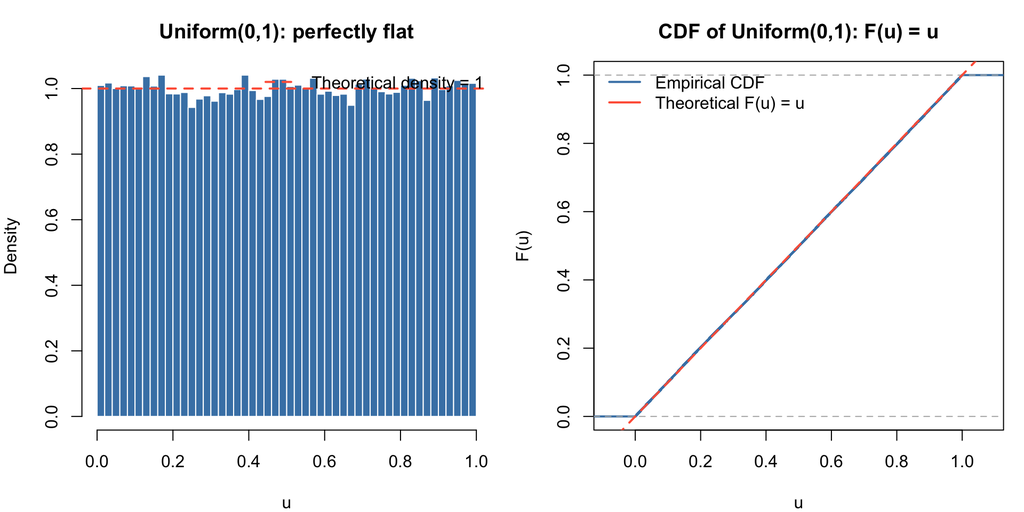

```r
U <- runif(N)

par(mfrow = c(1, 2), mar = c(4, 4, 3, 1))

hist(U, breaks = 60, col = "steelblue", border = "white", freq = FALSE,
     main = "Uniform(0,1): perfectly flat", xlab = "u", ylab = "Density")
abline(h = 1, col = "tomato", lwd = 2, lty = 2)
legend("topright", "Theoretical density = 1",
       col = "tomato", lwd = 2, lty = 2, bty = "n")

plot(ecdf(U), main = "CDF of Uniform(0,1): F(u) = u",
     xlab = "u", ylab = "F(u)", col = "steelblue", lwd = 2)
abline(0, 1, col = "tomato", lwd = 2, lty = 2)
legend("topleft", c("Empirical CDF", "Theoretical F(u) = u"),
       col = c("steelblue", "tomato"), lwd = 2, bty = "n")
```

# 2 变换：一个随机变量进，一个随机变量出

## 2.1 逆 CDF 变换（万能方法）

### 2.1.1 先说为什么要有这个变换：计算机只会掷”均匀骰子”

这个变换不是凭空的数学游戏，它来自**计算机模拟**的一个硬需求。

计算机的随机数发生器（RNG）**只会产生一种随机**：$U\sim\text{Uniform}(0,1)$——$[0,1]$ 上的均匀随机数。它天生**不会**直接吐指数分布、正态分布、泊松分布……那怎么办？

答案：**拿唯一能白拿的均匀随机，喂进逆 CDF，把它”掰”成你要的分布。**

$$U\sim\text{Uniform}(0,1)\ \xrightarrow{\
X=F^{-1}(U)\ }\ X\sim F.$$

所以这一节的主角其实是”**怎么用一个均匀骰子造出任意分布的随机数**”。$U$ 是**原料**，$F^{-1}$（逆 CDF / 分位函数）是**成型机**。一切都从 uniform（和由它造出的 normal）出发。

> **定理**：若 $U \sim \text{Uniform}(0,1)$，$F$ 是任意分布的 CDF，则 $X = F^{-1}(U) \sim F$。

> **说人话**：拿一个均匀随机数 $U$，喂进逆 CDF，得到的新随机数 $X=F^{-1}(U)$ **正好服从你想要的那个分布**。“$X \sim F$” 读作”$X$ 服从 $F$“，是一句话的缩写：$P(X\leq x)=F(x)$ 对所有 $x$ 成立——即 $X$ 出数的累积规律恰好由 $F$ 描述。

**记号**（三个东西类型完全不同，别混）：

- 大写 $X = F^{-1}(U)$ 是**随机变量**——会随机出数的”骰子”，每抽一次吐一个具体数（2.46, 0.34, …）。由随机的 $U$ 生成，本身也随机。目标是证明它服从分布 $F$。
- 小写 $x$ 是一个**任意但固定的实数**——横轴上一个具体的坐标点。证明中对它取遍所有值，从而通过 $P(X\leq x)=F(x)$（对每个 $x$ 都成立）确定 $X$ 的分布。

**先看直觉版**（假设 $F$ 连续、严格递增，绝大多数常见分布都满足）。核心那一步 $F^{-1}(U)\leq x \iff U\leq F(x)$ 就是**两边同时套 $F$**：

$$\begin{aligned}
F^{-1}(U)\leq x
&\iff F\!\left(F^{-1}(U)\right)\leq F(x)
&&\text{（}F\text{ 单调递增，两边套 }F\text{
保持}\leq\text{）}\\
&\iff U\leq F(x)
&&\text{（}F\text{ 与 }F^{-1}\text{
抵消：}F(F^{-1}(U))=U\text{）}.
\end{aligned}$$

第一步：$F$ 单调递增，所以 $a\leq b$ 与 $F(a)\leq F(b)$ 是一回事，两边套 $F$ 不改变不等号方向。 第二步：$F$ 和它的逆 $F^{-1}$ 互相抵消，$F(F^{-1}(U))$ 就还原成 $U$。

**再看严格版**（把连续、严格递增这两个假设也去掉）。用广义逆

$$F^{-1}(u)=\inf\{t:F(t)\geq
u\}$$

表示“CDF 第一次达到高度 $u$ 时的横坐标”。因此，固定任意 $x$，

$$\begin{aligned}
F^{-1}(U)\leq x
&\iff \text{CDF 在横坐标 }x\text{ 之前已经达到高度 }U\\
&\iff F(x)\geq U\\
&\iff U\leq F(x).
\end{aligned}$$

这两个不等式描述的是**同一个随机事件**，只是前者从横轴读，后者从纵轴读。于是

$$P(X\leq x)=P\!\left(F^{-1}(U)\leq
x\right)=P\!\left(U\leq F(x)\right)=F(x).$$

最后一步使用了 $U\sim\text{Uniform}(0,1)$：对任意 $a\in[0,1]$，$P(U\leq a)=a$。

**直觉**：$U$ 在概率轴 $[0,1]$ 上均匀采样，$F^{-1}$ 把概率值”翻译”回 $x$ 值。$F$ 越陡处密度越高，$F$ 越平处密度越低。

下图固定红色的 $x$。此时 CDF 已上升到红色高度 $F(x)$：

- 若抽到的 $U\leq F(x)$（紫色区域），从该高度向右碰到 CDF，再向下投影，落点一定在 $x$ 左侧，即 $F^{-1}(U)\leq x$。
- 若 $U>F(x)$（灰色示例），交点和落点都会在 $x$ 右侧。

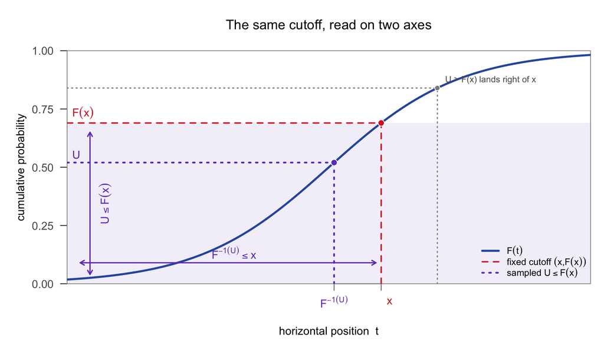

```r
t_grid <- seq(-4, 4, length.out = 1000)
F_grid <- plogis(t_grid)
x_cut <- 0.8
Fx_cut <- plogis(x_cut)
u_demo <- 0.52
x_demo <- qlogis(u_demo)
u_above <- 0.84
x_above <- qlogis(u_above)

op <- par(mar = c(4.8, 5, 3.8, 1))
plot(t_grid, F_grid, type = "n", xlim = c(-4, 4), ylim = c(0, 1),
     xlab = "horizontal position  t", ylab = "cumulative probability",
     main = expression("The same cutoff, read on two axes"),
     axes = FALSE, xaxs = "i", yaxs = "i")

# All possible U below F(x): the event U <= F(x).
rect(-4, 0, 4, Fx_cut,
     col = adjustcolor("#6F42C1", alpha.f = 0.09), border = NA)

axis(1, at = c(x_demo, x_cut), labels = FALSE, col = "gray35")
axis(2, at = c(0, 0.25, 0.5, 0.75, 1), las = 1,
     col.axis = "gray35")
box(col = "gray55")
lines(t_grid, F_grid, col = "#2E5AAC", lwd = 3)

# The fixed cutoff x and its CDF height F(x).
segments(x_cut, 0, x_cut, Fx_cut, col = "#D62728", lwd = 2, lty = 2)
segments(-4, Fx_cut, x_cut, Fx_cut, col = "#D62728", lwd = 2, lty = 2)
points(x_cut, Fx_cut, pch = 21, bg = "#D62728", col = "white", cex = 1.25)
text(x_cut + 0.13, -0.075, expression(x), col = "#D62728",
     font = 2, xpd = NA)
text(-3.92, Fx_cut + 0.045, expression(F(x)), col = "#D62728",
     font = 2, adj = 0)

# One sampled U <= F(x): horizontal to the CDF, then down to F^-1(U).
segments(-4, u_demo, x_demo, u_demo,
         col = "#6F42C1", lwd = 2.5, lty = 3)
segments(x_demo, 0, x_demo, u_demo,
         col = "#6F42C1", lwd = 2.5, lty = 3)
points(x_demo, u_demo, pch = 21, bg = "#6F42C1",
       col = "white", cex = 1.25)
text(-3.92, u_demo + 0.035, expression(U), col = "#6F42C1",
     font = 2, adj = 0)
text(x_demo, -0.075, expression(F^{-1}(U)), col = "#6F42C1",
     font = 2, xpd = NA)

# A counterexample to the event: U > F(x) maps to the right of x.
segments(-4, u_above, x_above, u_above,
         col = "gray55", lwd = 1.6, lty = 3)
segments(x_above, 0, x_above, u_above,
         col = "gray55", lwd = 1.6, lty = 3)
points(x_above, u_above, pch = 21, bg = "gray55",
       col = "white", cex = 1.05)
text(x_above + 0.12, u_above + 0.035,
     "U > F(x) lands right of x", col = "gray35", adj = 0, cex = 0.78)

# Labels that explicitly connect the two descriptions of the event.
arrows(-3.65, 0.04, -3.65, Fx_cut - 0.04, code = 3,
       length = 0.07, col = "#6F42C1", lwd = 1.8)
text(-3.42, Fx_cut / 2, expression(U <= F(x)),
     col = "#6F42C1", srt = 90, font = 2)
arrows(-3.8, 0.09, x_cut - 0.08, 0.09, code = 3,
       length = 0.07, col = "#6F42C1", lwd = 1.8)
text(-1.45, 0.135, expression(F^{-1}(U) <= x),
     col = "#6F42C1", font = 2)

legend("bottomright",
       legend = c(expression(F(t)), expression("fixed cutoff " * (x * "," * F(x))),
                  expression("sampled " * U <= F(x))),
       col = c("#2E5AAC", "#D62728", "#6F42C1"),
       lwd = c(3, 2, 2.5), lty = c(1, 2, 3),
       bty = "n", cex = 0.82)
```

```r
par(op)
```

图中为了直观使用连续 CDF；若 CDF 是阶梯状的，则把 $F^{-1}(u)$ 理解为“第一次达到或超过 $u$ 的位置”，上述事件等价仍然成立。

### 2.1.2 指数分布：手推解析逆 CDF

$F(x) = 1 - e^{-x}$。逆 CDF 做的事情是：**先给定纵轴上的累计概率 $u$，再反过来寻找横轴上的 $x$**。

逐步反解：

$$\begin{aligned}
u &= 1-e^{-x}\\
1-u &= e^{-x}\\
\log(1-u) &= -x\\
x &= -\log(1-u)
\end{aligned}$$

例如，$u=0.8$ 时，$x=-\log(0.2)\approx1.61$；也就是说，指数分布约有 80% 的概率落在 $[0,1.61]$ 内。

一张图讲完整条链，两列六格，所有面板同尺寸、坐标轴严格对齐。真实数据沿红色编号箭头走一个「П」形：**右下（输入）→ 右中（机器）→ 左中（竖着的输出）→ 左下（放倒的输出）**。把 Uniform 的 5 段颜色（各 20% 概率）从头贴上去：

- **右上 — CDF** $F(x)=1-e^{-x}$：横轴 $x$、纵轴 $u$。它和正下方机器图之间是竖直红色双箭头 `x <-> u axes flip`——机器图本身就是 inverse CDF，两轴对调直接上下对照。
- **右中 — inverse CDF = 机器（真实数据穿过）**：12 个真实 $U$ 各画一条轨迹——从 $u$ 轴竖直上升碰到曲线，再水平射向左边。底边小刻度是 400 个真实 $U$（均匀散开）。
- **右下 — 输入** $U\sim\text{Uniform}(0,1)$：5 个等宽色块 = 等概率。灰色细框是 10 万个真实 $U$ 的直方图——真数据不完美水平。
- **左中 — 输出（$x$ 轴竖着）**：和左下**同一张图、同一批数据、同一套颜色**，只是 $x$ 轴还竖着——竖轴与右边机器图的竖轴完全相同，机器射出的轨迹箭头直接落进来。灰色横条 = 10 万个真实 $-\log(1-U)$ 的直方图，贴着理论曲线 $e^{-x}$。
- **左下 — 输出（放倒）**：把左中整张图**顺时针转 90° 放平**，就是教科书里常见的指数密度图。红色箭头 `3. rotate 90 -> lay it flat` 标出这个动作。

**编号红箭头 = 真实数据流水线**：

1. `1. feed REAL uniform draws`（右下 ↑ 右中）：真实均匀数一个个喂进 $x=-\log(1-u)$——一次一个 log，**不求导**。
2. 右中 → 左中的无字红箭头：变换后的 $X$ 落在**同一根竖 $x$ 轴**上，直接数直方图——密度是数出来的。
3. `3. rotate 90 -> lay it flat`（左中 ↓ 左下）：把竖着的图放倒,得到常规密度图。**旋转只是排版动作，数学内容一丝不变。**

红点追踪：$u=0.8$ → $x=-\log(0.2)=1.61$ → 密度 $f(1.61)=0.2$，四张图里同一个红点。右上、左中右侧、右中右侧、左下 $x$ 轴上的红色刻度 $0,\,0.22,\,0.51,\,0.92,\,1.61$（band edges）是同一批 $x$ 分界。

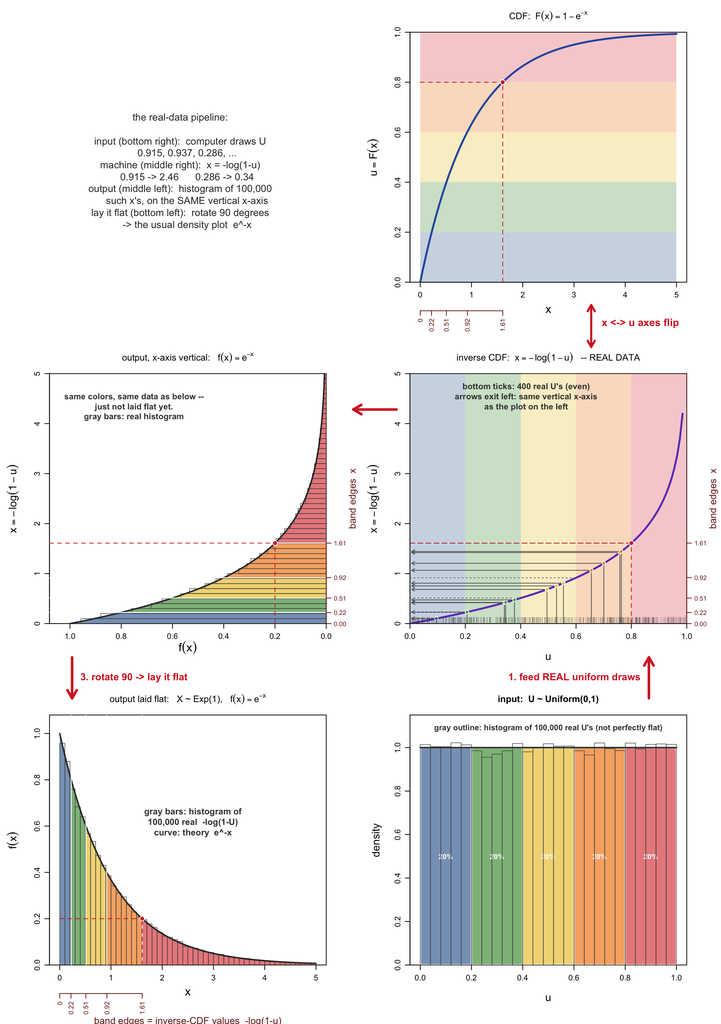

```r
prob_breaks<-seq(0,1,by=0.2);quantile_breaks<-qexp(prob_breaks,rate=1)
band_cols<-c("#4E79A7","#59A14F","#EDC948","#F28E2B","#E15759")
u_star<-0.8;x_star<- -log(1-u_star);tcol<-function(c,a)adjustcolor(c,alpha.f=a)
RED<-"#D62728";DRED<-"#7a1f1f"
# 3x2 grid, two equal columns. Every plot panel shares MAR -> columns align exactly.
layout(matrix(c(1,2, 3,4, 5,6),3,2,byrow=TRUE))
par(cex.lab=1.35,cex.main=1.15,cex.axis=1.0,mgp=c(3,0.8,0))
MAR <- c(6.2,5.2,3.4,3.6)

X_real <- -log(1-U)
h <- hist(X_real[X_real<=5],breaks=seq(0,5,by=0.1),plot=FALSE)
hs <- h$density*mean(X_real<=5)          # histogram heights, scaled to full density
u12 <- sort(runif(12)); x12 <- -log(1-u12)
u400 <- runif(400)

# (1) top-left: pipeline text
par(mar=c(2,2,2,2))
plot(NA,xlim=c(0,1),ylim=c(0,1),xlab="",ylab="",main="",axes=FALSE)
text(0.5,0.5,paste0(
 "the real-data pipeline:\n\n",
 "input (bottom right):  computer draws U\n",
 "     0.915, 0.937, 0.286, ...\n",
 "machine (middle right):  x = -log(1-u)\n",
 "     0.915 -> 2.46      0.286 -> 0.34\n",
 "output (middle left):  histogram of 100,000\n",
 "     such x's, on the SAME vertical x-axis\n",
 "lay it flat (bottom left):  rotate 90 degrees\n",
 "     -> the usual density plot  e^-x"),cex=1.25,col="gray20")

# (2) CDF, top right
par(mar=MAR)
plot(NA,xlim=c(0,5),ylim=c(0,1),xlab="",ylab=expression(u==F(x)),main=expression("CDF:  "*F(x)==1-e^{-x}),yaxs="i")
for(i in 1:5)rect(0,prob_breaks[i],5,prob_breaks[i+1],col=tcol(band_cols[i],0.30),border=NA)
curve(1-exp(-x),0,5,add=TRUE,lwd=2.6,col="#2E5AAC")
segments(0,u_star,x_star,u_star,lty=2,col=RED);segments(x_star,0,x_star,u_star,lty=2,col=RED);points(x_star,u_star,pch=21,bg=RED,col="white",cex=1.3)
mtext(expression(x),side=1,line=2.4,cex=0.95)
axis(1,at=round(quantile_breaks[1:5],2),labels=round(quantile_breaks[1:5],2),las=2,line=3.0,cex.axis=0.85,col.axis=DRED,col=DRED)

# (3) OUTPUT STOOD UPRIGHT, middle left: same plot as bottom, x-axis VERTICAL
par(mar=MAR)
plot(NA,xlim=c(1.08,0),ylim=c(0,5),xlab="",ylab=expression(x==-log(1-u)),
     main=expression("output, x-axis vertical:   "*f(x)==e^{-x}),yaxs="i",xaxs="i")
for(i in 1:5){
  l<-quantile_breaks[i];r<-min(quantile_breaks[i+1],5)
  xx<-seq(l,r,length.out=150)
  polygon(c(0,dexp(xx),0),c(l,xx,r),col=tcol(band_cols[i],0.72),border=NA)
}
rect(hs,h$breaks[-length(h$breaks)],0,h$breaks[-1],border="gray30",col=NA,lwd=0.7)
xg<-seq(0,5,length.out=400); lines(dexp(xg),xg,lwd=2,col="gray20")
abline(h=quantile_breaks[2:5],col="white",lwd=1.2)
f_star<-dexp(x_star)
segments(f_star,0,f_star,x_star,lty=2,col=RED);segments(1.08,x_star,f_star,x_star,lty=2,col=RED)
points(f_star,x_star,pch=21,bg=RED,col="white",cex=1.3)
mtext(expression(f(x)),side=1,line=2.4,cex=0.95)
axis(4,at=round(quantile_breaks[1:5],2),las=1,cex.axis=0.8,col.axis=DRED,col=DRED)
mtext("band edges  x",side=4,line=2.3,cex=0.80,col=DRED)
text(0.75,4.35,"same colors, same data as below --\njust not laid flat yet.\ngray bars: real histogram",cex=1.05,col="gray25",font=2)

# (4) inverse CDF = MACHINE with real data, middle right
par(mar=MAR)
plot(NA,xlim=c(0,1),ylim=c(0,5),xlab=expression(u),ylab=expression(x==-log(1-u)),
     main=expression("inverse CDF:  "*x==-log(1-u)*"   -- REAL DATA"),yaxs="i",xaxs="i")
for(i in 1:5)rect(prob_breaks[i],0,prob_breaks[i+1],5,col=tcol(band_cols[i],0.30),border=NA)
curve(-log(1-x),0,0.985,add=TRUE,lwd=2.6,col="#6F42C1")
for(i in 2:5)segments(0,quantile_breaks[i],prob_breaks[i],quantile_breaks[i],lty=3,col="gray40")
for(j in 1:12){
  segments(u12[j],0,u12[j],x12[j],col="gray35",lwd=0.9)
  arrows(u12[j],x12[j],0.006,x12[j],length=0.05,col="gray35",lwd=0.9)
  points(u12[j],x12[j],pch=21,bg=band_cols[findInterval(u12[j],prob_breaks,rightmost.closed=TRUE)],col="white",cex=1.0)
}
rug(u400,side=1,ticksize=0.025,col=tcol("gray20",0.35),lwd=0.6)
axis(4,at=round(quantile_breaks[1:5],2),las=1,cex.axis=0.8,col.axis=DRED,col=DRED)
mtext("band edges  x",side=4,line=2.3,cex=0.80,col=DRED)
segments(u_star,0,u_star,x_star,lty=2,col=RED);segments(0,x_star,u_star,x_star,lty=2,col=RED);points(u_star,x_star,pch=21,bg=RED,col="white",cex=1.3)
text(0.42,4.55,"bottom ticks: 400 real U's (even)\narrows exit left: same vertical x-axis\nas the plot on the left",cex=1.05,col="gray25",font=2)

# (5) OUTPUT LAID FLAT, bottom left: the usual density plot
par(mar=MAR)
plot(NA,xlim=c(0,5),ylim=c(0,1.08),xlab="",ylab=expression(f(x)),
     main=expression("output laid flat:   X ~ Exp(1),   "*f(x)==e^{-x}),yaxs="i")
for(i in 1:5){l<-quantile_breaks[i];r<-min(quantile_breaks[i+1],5);xx<-seq(l,r,length.out=150);polygon(c(l,xx,r),c(0,dexp(xx),0),col=tcol(band_cols[i],0.72),border=NA)}
rect(h$breaks[-length(h$breaks)],0,h$breaks[-1],hs,border="gray30",col=NA,lwd=0.7)
curve(dexp(x),0,5,add=TRUE,lwd=2,col="gray20")
abline(v=quantile_breaks[2:5],col="white",lwd=1.2)
segments(x_star,0,x_star,f_star,lty=2,col=RED);segments(0,f_star,x_star,f_star,lty=2,col=RED);points(x_star,f_star,pch=21,bg=RED,col="white",cex=1.3)
text(2.6,0.62,"gray bars: histogram of\n100,000 real  -log(1-U)\ncurve: theory  e^-x",cex=1.1,col="gray25",font=2)
mtext(expression(x),side=1,line=2.4,cex=0.95)
axis(1,at=round(quantile_breaks[1:5],2),labels=round(quantile_breaks[1:5],2),las=2,line=3.0,cex.axis=0.85,col.axis=DRED,col=DRED)
mtext("band edges = inverse-CDF values  -log(1-u)",side=1,line=5.4,cex=0.80,col=DRED)

# (6) INPUT uniform, bottom right
par(mar=MAR)
plot(NA,xlim=c(0,1),ylim=c(0,1.15),xlab=expression(u),ylab="density",main="input:  U ~ Uniform(0,1)",yaxs="i")
for(i in 1:5){rect(prob_breaks[i],0,prob_breaks[i+1],1,col=tcol(band_cols[i],0.72),border="white",lwd=2);text(mean(prob_breaks[i:(i+1)]),0.5,"20%",col="white",font=2,cex=0.9)}
h_u <- hist(U,breaks=seq(0,1,by=0.04),plot=FALSE)
rect(h_u$breaks[-length(h_u$breaks)],0,h_u$breaks[-1],h_u$density,border="gray30",col=NA,lwd=0.7)
segments(0,1,1,1,lwd=2,col="gray25")
text(0.5,1.09,"gray outline: histogram of 100,000 real U's (not perfectly flat)",cex=1.0,col="gray25",font=2)

# overlays
par(fig=c(0,1,0,1),new=TRUE,mar=c(0,0,0,0));plot(0:1,0:1,type="n",axes=FALSE,xlim=c(0,1),ylim=c(0,1),xaxs="i",yaxs="i")
# flip: CDF <-> machine (right column, rows 1-2)
arrows(0.82,0.702,0.82,0.661,code=3,length=0.10,lwd=2.8,col=RED)
text(0.828,0.684,"x <-> u axes flip",cex=1.3,col=RED,font=2,pos=4)
# 1. uniform -> machine (right column, rows 3->2)
arrows(0.90,0.318,0.90,0.358,length=0.13,lwd=3.4,col=RED)
text(0.895,0.338,"1. feed REAL uniform draws",cex=1.25,col=RED,font=2,pos=2)
# 2. machine -> upright output (middle row, right -> left)
arrows(0.550,0.60,0.490,0.60,length=0.13,lwd=3.4,col=RED)
# 3. upright -> laid flat (left column, rows 2->3)
arrows(0.10,0.358,0.10,0.318,length=0.13,lwd=3.4,col=RED)
text(0.105,0.338,"3. rotate 90 -> lay it flat",cex=1.25,col=RED,font=2,pos=4)
```

```r
layout(1)
```

```r
# The hand-rolled inverse CDF and R's qexp are the same formula.
X_exp_hand <- -log(1 - U)
X_exp_qexp <- qexp(U, rate = 1)
cat("Max | -log(1-U) - qexp(U) | =",
    max(abs(X_exp_hand - X_exp_qexp)), "\n")
```

```
## Max | -log(1-U) - qexp(U) | = 0
```

注意两个端点：$u=0$ 映射到 $x=0$；当 $u\to1$ 时，$1-u\to0$，所以 $-\log(1-u)\to\infty$。这正是指数分布右侧长尾的来源。`qexp(u, rate = 1)` 只是同一个公式的 R 实现，不是另一种生成机制。

### 2.1.3 Weibull：在指数逆 CDF 上再做幂变换

Weibull$(k, \lambda)$ 的 CDF：$F(x) = 1 - e^{-(x/\lambda)^k}$，反解得：

$$F^{-1}(u) = \lambda \cdot
\bigl(-\log(1-u)\bigr)^{1/k}$$

也就是说：**Weibull 的逆 CDF = 指数逆 CDF 的 $1/k$ 次方**。

下面把 exp 那张流水线图**原样复刻一遍**，只把机器换成 Weibull 的逆 CDF（$k=2,\ \lambda=1$）。看点是**同一条流水线，只多了一个开方**：

- **机器**变成 $x=\sqrt{-\log(1-u)}$ ——就是 exp 机器的输出再开平方。开方把 exp 的大值压扁（$2.46\to1.57$），长尾被收紧。
- **CDF 变成 S 形**（有拐点），exp 的 CDF 没有。
- **密度有峰了**（峰在 $x=1/\sqrt2\approx0.71$），不再像 exp 那样在 0 处最高、一路单调跌。
- 红点照旧追踪 $u=0.8\to x=\sqrt{1.61}=1.27\to f(1.27)=0.51$；band edges $0,\,0.47,\,0.71,\,0.96,\,1.27$ 正是 exp 那批 $0,\,0.22,\,0.51,\,0.92,\,1.61$ 的**平方根**。

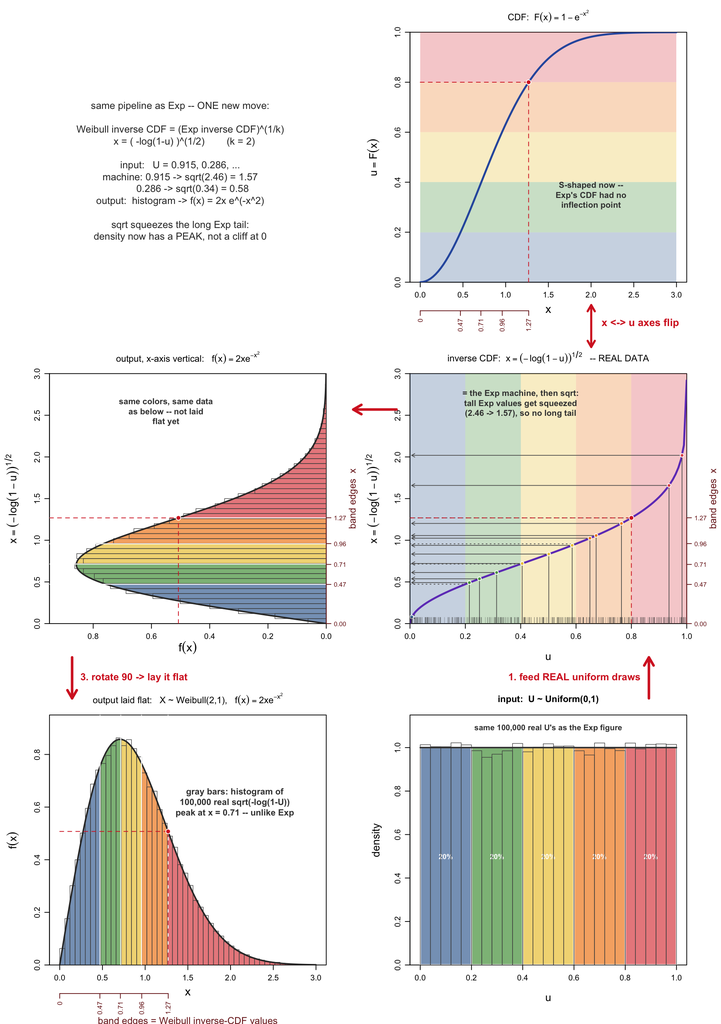

```r
k <- 2; lam <- 1
prob_breaks <- seq(0,1,by=0.2); wq <- qweibull(prob_breaks,k,lam)
band_cols <- c("#4E79A7","#59A14F","#EDC948","#F28E2B","#E15759")
u_star <- 0.8; xw_star <- qweibull(u_star,k,lam)     # 1.269
tcol <- function(c,a) adjustcolor(c,alpha.f=a)
RED<-"#D62728"; DRED<-"#7a1f1f"; XM <- 3
layout(matrix(c(1,2, 3,4, 5,6),3,2,byrow=TRUE))
par(cex.lab=1.35,cex.main=1.15,cex.axis=1.0,mgp=c(3,0.8,0))
MAR <- c(6.2,5.2,3.4,3.6)

W_real <- qweibull(U,k,lam)                          # = sqrt(-log(1-U))
hw <- hist(W_real[W_real<=XM],breaks=seq(0,XM,by=0.06),plot=FALSE)
hws <- hw$density*mean(W_real<=XM)
u12 <- sort(runif(12)); w12 <- qweibull(u12,k,lam)
u400 <- runif(400)

# (1) pipeline text
par(mar=c(2,2,2,2))
plot(NA,xlim=c(0,1),ylim=c(0,1),xlab="",ylab="",main="",axes=FALSE)
text(0.5,0.5,paste0(
 "same pipeline as Exp -- ONE new move:\n\n",
 "Weibull inverse CDF = (Exp inverse CDF)^(1/k)\n",
 "   x = ( -log(1-u) )^(1/2)        (k = 2)\n\n",
 "input:   U = 0.915, 0.286, ...\n",
 "machine: 0.915 -> sqrt(2.46) = 1.57\n",
 "         0.286 -> sqrt(0.34) = 0.58\n",
 "output:  histogram -> f(x) = 2x e^(-x^2)\n\n",
 "sqrt squeezes the long Exp tail:\n",
 "density now has a PEAK, not a cliff at 0"),cex=1.25,col="gray20")

# (2) CDF, top right
par(mar=MAR)
plot(NA,xlim=c(0,XM),ylim=c(0,1),xlab="",ylab=expression(u==F(x)),
     main=expression("CDF:  "*F(x)==1-e^{-x^2}),yaxs="i")
for(i in 1:5)rect(0,prob_breaks[i],XM,prob_breaks[i+1],col=tcol(band_cols[i],0.30),border=NA)
curve(pweibull(x,k,lam),0,XM,add=TRUE,lwd=2.6,col="#2E5AAC")
segments(0,u_star,xw_star,u_star,lty=2,col=RED);segments(xw_star,0,xw_star,u_star,lty=2,col=RED)
points(xw_star,u_star,pch=21,bg=RED,col="white",cex=1.3)
mtext(expression(x),side=1,line=2.4,cex=0.95)
axis(1,at=round(wq[1:5],2),labels=round(wq[1:5],2),las=2,line=3.0,cex.axis=0.85,col.axis=DRED,col=DRED)
text(2.0,0.35,"S-shaped now --\nExp's CDF had no\ninflection point",cex=1.05,col="gray25",font=2)

# (3) OUTPUT upright, middle left
par(mar=MAR)
plot(NA,xlim=c(0.95,0),ylim=c(0,XM),xlab="",ylab=expression(x==(-log(1-u))^{1/2}),
     main=expression("output, x-axis vertical:   "*f(x)==2*x*e^{-x^2}),yaxs="i",xaxs="i")
for(i in 1:5){
  l<-wq[i];r<-min(wq[i+1],XM); xx<-seq(l,r,length.out=150)
  polygon(c(0,dweibull(xx,k,lam),0),c(l,xx,r),col=tcol(band_cols[i],0.72),border=NA)
}
rect(hws,hw$breaks[-length(hw$breaks)],0,hw$breaks[-1],border="gray30",col=NA,lwd=0.7)
xg<-seq(0,XM,length.out=400); lines(dweibull(xg,k,lam),xg,lwd=2,col="gray20")
abline(h=wq[2:5],col="white",lwd=1.2)
fw_star<-dweibull(xw_star,k,lam)
segments(fw_star,0,fw_star,xw_star,lty=2,col=RED);segments(0.95,xw_star,fw_star,xw_star,lty=2,col=RED)
points(fw_star,xw_star,pch=21,bg=RED,col="white",cex=1.3)
mtext(expression(f(x)),side=1,line=2.4,cex=0.95)
axis(4,at=round(wq[1:5],2),las=1,cex.axis=0.8,col.axis=DRED,col=DRED)
mtext("band edges  x",side=4,line=2.3,cex=0.80,col=DRED)
text(0.55,2.55,"same colors, same data\nas below -- not laid\nflat yet",cex=1.05,col="gray25",font=2)

# (4) MACHINE, middle right
par(mar=MAR)
plot(NA,xlim=c(0,1),ylim=c(0,XM),xlab=expression(u),ylab=expression(x==(-log(1-u))^{1/2}),
     main=expression("inverse CDF:  "*x==(-log(1-u))^{1/2}*"   -- REAL DATA"),yaxs="i",xaxs="i")
for(i in 1:5)rect(prob_breaks[i],0,prob_breaks[i+1],XM,col=tcol(band_cols[i],0.30),border=NA)
curve(qweibull(x,k,lam),0,0.9998,add=TRUE,lwd=2.6,col="#6F42C1")
for(i in 2:5)segments(0,wq[i],prob_breaks[i],wq[i],lty=3,col="gray40")
for(j in 1:12){
  segments(u12[j],0,u12[j],w12[j],col="gray35",lwd=0.9)
  arrows(u12[j],w12[j],0.006,w12[j],length=0.05,col="gray35",lwd=0.9)
  points(u12[j],w12[j],pch=21,bg=band_cols[findInterval(u12[j],prob_breaks,rightmost.closed=TRUE)],col="white",cex=1.0)
}
rug(u400,side=1,ticksize=0.025,col=tcol("gray20",0.35),lwd=0.6)
axis(4,at=round(wq[1:5],2),las=1,cex.axis=0.8,col.axis=DRED,col=DRED)
mtext("band edges  x",side=4,line=2.3,cex=0.80,col=DRED)
segments(u_star,0,u_star,xw_star,lty=2,col=RED);segments(0,xw_star,u_star,xw_star,lty=2,col=RED)
points(u_star,xw_star,pch=21,bg=RED,col="white",cex=1.3)
text(0.40,2.65,"= the Exp machine, then sqrt:\ntall Exp values get squeezed\n(2.46 -> 1.57), so no long tail",cex=1.05,col="gray25",font=2)

# (5) OUTPUT laid flat, bottom left
par(mar=MAR)
plot(NA,xlim=c(0,XM),ylim=c(0,0.95),xlab="",ylab=expression(f(x)),
     main=expression("output laid flat:   X ~ Weibull(2,1),   "*f(x)==2*x*e^{-x^2}),yaxs="i")
for(i in 1:5){l<-wq[i];r<-min(wq[i+1],XM);xx<-seq(l,r,length.out=150)
  polygon(c(l,xx,r),c(0,dweibull(xx,k,lam),0),col=tcol(band_cols[i],0.72),border=NA)}
rect(hw$breaks[-length(hw$breaks)],0,hw$breaks[-1],hws,border="gray30",col=NA,lwd=0.7)
curve(dweibull(x,k,lam),0,XM,add=TRUE,lwd=2,col="gray20")
abline(v=wq[2:5],col="white",lwd=1.2)
segments(xw_star,0,xw_star,fw_star,lty=2,col=RED);segments(0,fw_star,xw_star,fw_star,lty=2,col=RED)
points(xw_star,fw_star,pch=21,bg=RED,col="white",cex=1.3)
text(2.05,0.62,"gray bars: histogram of\n100,000 real sqrt(-log(1-U))\npeak at x = 0.71 -- unlike Exp",cex=1.1,col="gray25",font=2)
mtext(expression(x),side=1,line=2.4,cex=0.95)
axis(1,at=round(wq[1:5],2),labels=round(wq[1:5],2),las=2,line=3.0,cex.axis=0.85,col.axis=DRED,col=DRED)
mtext("band edges = Weibull inverse-CDF values",side=1,line=5.4,cex=0.80,col=DRED)

# (6) INPUT uniform, bottom right
par(mar=MAR)
plot(NA,xlim=c(0,1),ylim=c(0,1.15),xlab=expression(u),ylab="density",main="input:  U ~ Uniform(0,1)",yaxs="i")
for(i in 1:5){rect(prob_breaks[i],0,prob_breaks[i+1],1,col=tcol(band_cols[i],0.72),border="white",lwd=2)
  text(mean(prob_breaks[i:(i+1)]),0.5,"20%",col="white",font=2,cex=0.9)}
h_u <- hist(U,breaks=seq(0,1,by=0.04),plot=FALSE)
rect(h_u$breaks[-length(h_u$breaks)],0,h_u$breaks[-1],h_u$density,border="gray30",col=NA,lwd=0.7)
segments(0,1,1,1,lwd=2,col="gray25")
text(0.5,1.09,"same 100,000 real U's as the Exp figure",cex=1.0,col="gray25",font=2)

# overlays
par(fig=c(0,1,0,1),new=TRUE,mar=c(0,0,0,0));plot(0:1,0:1,type="n",axes=FALSE,xlim=c(0,1),ylim=c(0,1),xaxs="i",yaxs="i")
arrows(0.82,0.702,0.82,0.661,code=3,length=0.10,lwd=2.8,col=RED)
text(0.828,0.684,"x <-> u axes flip",cex=1.3,col=RED,font=2,pos=4)
arrows(0.90,0.318,0.90,0.358,length=0.13,lwd=3.4,col=RED)
text(0.895,0.338,"1. feed REAL uniform draws",cex=1.25,col=RED,font=2,pos=2)
arrows(0.550,0.60,0.490,0.60,length=0.13,lwd=3.4,col=RED)
arrows(0.10,0.358,0.10,0.318,length=0.13,lwd=3.4,col=RED)
text(0.105,0.338,"3. rotate 90 -> lay it flat",cex=1.25,col=RED,font=2,pos=4)
```

```r
layout(1)
```

```r
k <- 2; lambda <- 1
X_wei_hand <- lambda * (-log(1 - U))^(1/k)
X_wei_qwei <- qweibull(U, shape = k, scale = lambda)

cat("Max absolute difference (should be ~0):",
    max(abs(X_wei_hand - X_wei_qwei)), "\n")
```

```
## Max absolute difference (should be ~0): 0
```

### 2.1.4 正态分布：数值逆 CDF

$\Phi(x) = \int_{-\infty}^x \frac{1}{\sqrt{2\pi}} e^{-t^2/2} dt$ 没有闭合形式。`qnorm(u)` 用有理函数近似计算 $\Phi^{-1}(u)$。**概念完全一样**：给定概率 $u$，找满足 $\Phi(x) = u$ 的 $x$。

```r
p_in  <- c(0.025, 0.16, 0.50, 0.84, 0.975)
x_out <- qnorm(p_in)

data.frame(
  p_input         = p_in,
  "qnorm(p)"      = round(x_out, 4),
  "pnorm(qnorm(p))" = round(pnorm(x_out), 6)
)
```

```
##   p_input qnorm.p. pnorm.qnorm.p..
## 1   0.025  -1.9600           0.025
## 2   0.160  -0.9945           0.160
## 3   0.500   0.0000           0.500
## 4   0.840   0.9945           0.840
## 5   0.975   1.9600           0.975
```

还是那条流水线，第三遍。这次的新点只有一个：**$\Phi^{-1}$ 没有解析式，机器是数值解**——`qnorm(u)` 在内部解方程 $\Phi(x)=u$。流程完全没变：

- **CDF 对称 S 形**，在 $x=0$ 处最陡 → 中间那条 20% 带（$-0.25\sim0.25$）在 $x$ 轴上**最窄**，密度峰就在这。
- **两头都摊向无穷**：最外两条带各自伸向 $\pm\infty$——正态是双尾，exp/Weibull 只有右尾。
- 红点照旧：$u=0.8\to x=\Phi^{-1}(0.8)=0.84\to f(0.84)=0.28$；band edges $\pm0.84,\ \pm0.25$ 左右对称。

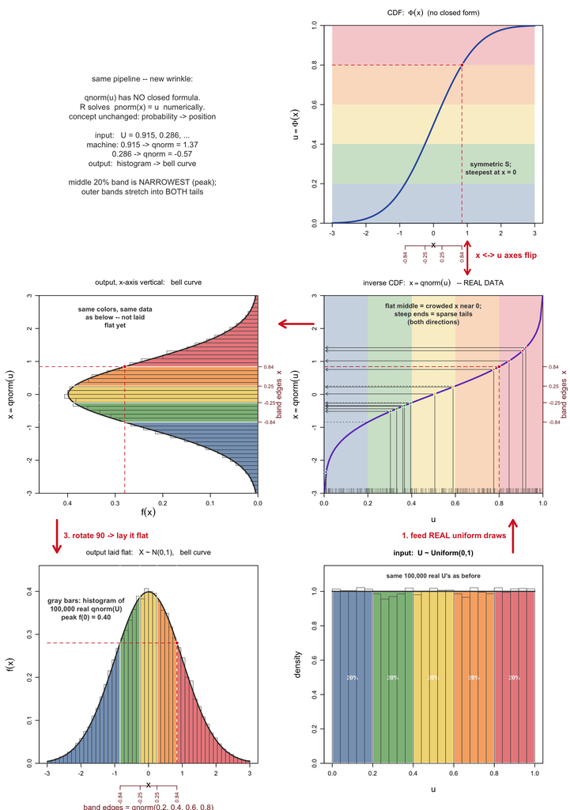

```r
prob_breaks <- seq(0,1,by=0.2); nq <- qnorm(prob_breaks)      # -Inf ... Inf
nq_fin <- nq[2:5]                                             # -0.84 -0.25 0.25 0.84
band_cols <- c("#4E79A7","#59A14F","#EDC948","#F28E2B","#E15759")
u_star <- 0.8; xn_star <- qnorm(u_star); fn_star <- dnorm(xn_star)
tcol <- function(c,a) adjustcolor(c,alpha.f=a)
RED<-"#D62728"; DRED<-"#7a1f1f"; XL <- -3; XR <- 3
layout(matrix(c(1,2, 3,4, 5,6),3,2,byrow=TRUE))
par(cex.lab=1.35,cex.main=1.15,cex.axis=1.0,mgp=c(3,0.8,0))
MAR <- c(6.2,5.2,3.4,3.6)

N_real <- qnorm(U)
hn <- hist(N_real[abs(N_real)<=XR],breaks=seq(XL,XR,by=0.12),plot=FALSE)
hns <- hn$density*mean(abs(N_real)<=XR)
u12 <- sort(runif(12)); n12 <- pmin(pmax(qnorm(u12),XL),XR)
u400 <- runif(400)

# (1) pipeline text
par(mar=c(2,2,2,2))
plot(NA,xlim=c(0,1),ylim=c(0,1),xlab="",ylab="",main="",axes=FALSE)
text(0.5,0.5,paste0(
 "same pipeline -- new wrinkle:\n\n",
 "qnorm(u) has NO closed formula.\n",
 "R solves  pnorm(x) = u  numerically.\n",
 "concept unchanged: probability -> position\n\n",
 "input:   U = 0.915, 0.286, ...\n",
 "machine: 0.915 -> qnorm = 1.37\n",
 "         0.286 -> qnorm = -0.57\n",
 "output:  histogram -> bell curve\n\n",
 "middle 20% band is NARROWEST (peak);\n",
 "outer bands stretch into BOTH tails"),cex=1.25,col="gray20")

# (2) CDF, top right
par(mar=MAR)
plot(NA,xlim=c(XL,XR),ylim=c(0,1),xlab="",ylab=expression(u==Phi(x)),
     main=expression("CDF:  "*Phi(x)*"  (no closed form)"),yaxs="i")
for(i in 1:5)rect(XL,prob_breaks[i],XR,prob_breaks[i+1],col=tcol(band_cols[i],0.30),border=NA)
curve(pnorm(x),XL,XR,add=TRUE,lwd=2.6,col="#2E5AAC")
segments(XL,u_star,xn_star,u_star,lty=2,col=RED);segments(xn_star,0,xn_star,u_star,lty=2,col=RED)
points(xn_star,u_star,pch=21,bg=RED,col="white",cex=1.3)
mtext(expression(x),side=1,line=2.4,cex=0.95)
axis(1,at=round(nq_fin,2),labels=round(nq_fin,2),las=2,line=3.0,cex.axis=0.85,col.axis=DRED,col=DRED)
text(1.7,0.28,"symmetric S;\nsteepest at x = 0",cex=1.05,col="gray25",font=2)

# (3) OUTPUT upright, middle left
par(mar=MAR)
plot(NA,xlim=c(0.46,0),ylim=c(XL,XR),xlab="",ylab=expression(x==qnorm(u)),
     main=expression("output, x-axis vertical:   bell curve"),yaxs="i",xaxs="i")
for(i in 1:5){
  l<-max(nq[i],XL);r<-min(nq[i+1],XR); xx<-seq(l,r,length.out=150)
  polygon(c(0,dnorm(xx),0),c(l,xx,r),col=tcol(band_cols[i],0.72),border=NA)
}
rect(hns,hn$breaks[-length(hn$breaks)],0,hn$breaks[-1],border="gray30",col=NA,lwd=0.7)
xg<-seq(XL,XR,length.out=400); lines(dnorm(xg),xg,lwd=2,col="gray20")
abline(h=nq_fin,col="white",lwd=1.2)
segments(fn_star,XL,fn_star,xn_star,lty=2,col=RED);segments(0.46,xn_star,fn_star,xn_star,lty=2,col=RED)
points(fn_star,xn_star,pch=21,bg=RED,col="white",cex=1.3)
mtext(expression(f(x)),side=1,line=2.4,cex=0.95)
axis(4,at=round(nq_fin,2),las=1,cex.axis=0.8,col.axis=DRED,col=DRED)
mtext("band edges  x",side=4,line=2.3,cex=0.80,col=DRED)
text(0.30,2.35,"same colors, same data\nas below -- not laid\nflat yet",cex=1.05,col="gray25",font=2)

# (4) MACHINE, middle right
par(mar=MAR)
plot(NA,xlim=c(0,1),ylim=c(XL,XR),xlab=expression(u),ylab=expression(x==qnorm(u)),
     main=expression("inverse CDF:  "*x==qnorm(u)*"   -- REAL DATA"),yaxs="i",xaxs="i")
for(i in 1:5)rect(prob_breaks[i],XL,prob_breaks[i+1],XR,col=tcol(band_cols[i],0.30),border=NA)
curve(qnorm(x),0.0015,0.9985,add=TRUE,lwd=2.6,col="#6F42C1")
for(i in 2:5)segments(0,nq[i],prob_breaks[i],nq[i],lty=3,col="gray40")
for(j in 1:12){
  segments(u12[j],XL,u12[j],n12[j],col="gray35",lwd=0.9)
  arrows(u12[j],n12[j],0.006,n12[j],length=0.05,col="gray35",lwd=0.9)
  points(u12[j],n12[j],pch=21,bg=band_cols[findInterval(u12[j],prob_breaks,rightmost.closed=TRUE)],col="white",cex=1.0)
}
rug(u400,side=1,ticksize=0.025,col=tcol("gray20",0.35),lwd=0.6)
axis(4,at=round(nq_fin,2),las=1,cex.axis=0.8,col.axis=DRED,col=DRED)
mtext("band edges  x",side=4,line=2.3,cex=0.80,col=DRED)
segments(u_star,XL,u_star,xn_star,lty=2,col=RED);segments(0,xn_star,u_star,xn_star,lty=2,col=RED)
points(u_star,xn_star,pch=21,bg=RED,col="white",cex=1.3)
text(0.50,2.45,"flat middle = crowded x near 0;\nsteep ends = sparse tails\n(both directions)",cex=1.05,col="gray25",font=2)

# (5) OUTPUT laid flat, bottom left
par(mar=MAR)
plot(NA,xlim=c(XL,XR),ylim=c(0,0.46),xlab="",ylab=expression(f(x)),
     main=expression("output laid flat:   X ~ N(0,1),   bell curve"),yaxs="i")
for(i in 1:5){l<-max(nq[i],XL);r<-min(nq[i+1],XR);xx<-seq(l,r,length.out=150)
  polygon(c(l,xx,r),c(0,dnorm(xx),0),col=tcol(band_cols[i],0.72),border=NA)}
rect(hn$breaks[-length(hn$breaks)],0,hn$breaks[-1],hns,border="gray30",col=NA,lwd=0.7)
curve(dnorm(x),XL,XR,add=TRUE,lwd=2,col="gray20")
abline(v=nq_fin,col="white",lwd=1.2)
segments(xn_star,0,xn_star,fn_star,lty=2,col=RED);segments(XL,fn_star,xn_star,fn_star,lty=2,col=RED)
points(xn_star,fn_star,pch=21,bg=RED,col="white",cex=1.3)
text(-1.85,0.36,"gray bars: histogram of\n100,000 real qnorm(U)\npeak f(0) = 0.40",cex=1.1,col="gray25",font=2)
mtext(expression(x),side=1,line=2.4,cex=0.95)
axis(1,at=round(nq_fin,2),labels=round(nq_fin,2),las=2,line=3.0,cex.axis=0.85,col.axis=DRED,col=DRED)
mtext("band edges = qnorm(0.2, 0.4, 0.6, 0.8)",side=1,line=5.4,cex=0.80,col=DRED)

# (6) INPUT uniform, bottom right
par(mar=MAR)
plot(NA,xlim=c(0,1),ylim=c(0,1.15),xlab=expression(u),ylab="density",main="input:  U ~ Uniform(0,1)",yaxs="i")
for(i in 1:5){rect(prob_breaks[i],0,prob_breaks[i+1],1,col=tcol(band_cols[i],0.72),border="white",lwd=2)
  text(mean(prob_breaks[i:(i+1)]),0.5,"20%",col="white",font=2,cex=0.9)}
h_u <- hist(U,breaks=seq(0,1,by=0.04),plot=FALSE)
rect(h_u$breaks[-length(h_u$breaks)],0,h_u$breaks[-1],h_u$density,border="gray30",col=NA,lwd=0.7)
segments(0,1,1,1,lwd=2,col="gray25")
text(0.5,1.09,"same 100,000 real U's as before",cex=1.0,col="gray25",font=2)

# overlays
par(fig=c(0,1,0,1),new=TRUE,mar=c(0,0,0,0));plot(0:1,0:1,type="n",axes=FALSE,xlim=c(0,1),ylim=c(0,1),xaxs="i",yaxs="i")
arrows(0.82,0.702,0.82,0.661,code=3,length=0.10,lwd=2.8,col=RED)
text(0.828,0.684,"x <-> u axes flip",cex=1.3,col=RED,font=2,pos=4)
arrows(0.90,0.318,0.90,0.358,length=0.13,lwd=3.4,col=RED)
text(0.895,0.338,"1. feed REAL uniform draws",cex=1.25,col=RED,font=2,pos=2)
arrows(0.550,0.60,0.490,0.60,length=0.13,lwd=3.4,col=RED)
arrows(0.10,0.358,0.10,0.318,length=0.13,lwd=3.4,col=RED)
text(0.105,0.338,"3. rotate 90 -> lay it flat",cex=1.25,col=RED,font=2,pos=4)
```

```r
layout(1)
```

### 2.1.5 为什么”数直方图”就是”求导”

正态这张图把一个悬了很久的问题逼到明面上：右图是 S 形曲线，左图是钟形——**显然不是 copy**。左图到底是怎么从右图”算”出来的？答案：直方图的每根柱子，物理上就是一条割线斜率。

**1. 一根柱子在算什么。** density 直方图的柱高定义是

$$\text{柱高}=\frac{\text{掉进桶里的样本占比}}{\text{桶宽}}=\frac{\Delta
u}{\Delta x}$$

——这正是导数的差商 $\frac{F(x+\Delta)-F(x)}{\Delta}$，一个字不差。求导藏在柱高的**除法**里：一整排柱子 = 逐段读出的 $F$ 的斜率 = $f$。

**2. 随机数干了什么：丈量分子 $\Delta u$。** 均匀数的特权是”落进任何 $u$ 区间的点数占比 = 区间长度”。机器 $F^{-1}$ 把 $u$ 轴上长 $\Delta u$ 的一段搬到 $x$ 轴上宽 $\Delta x$ 的一桶（图里的横箭头就是搬运工），于是**数桶里的点数 = 量出 $\Delta u$**。除以已知的桶宽，柱高 $=\Delta u/\Delta x$。

**3. 用 exp 的数验一遍。** 桶 $[1.5,\,1.6]$，宽 $0.1$：$\Delta u=e^{-1.5}-e^{-1.6}=0.2231-0.2019=0.0212$，所以 10 万样本里约 **2120 个**落在这桶，柱高 $=0.0212/0.1=0.212$；而 $f(1.55)=e^{-1.55}=0.212$。数出来的柱子 = 那一点的导数。

**4. 箭头视角。** 右图横箭头在 $u$ 轴上等间距出发；穿过曲线后落在竖 $x$ 轴上的间距 = 机器斜率 $Q'$。“单位 $x$ 里几根箭头” = 间距的倒数 = $1/Q'=F'(x)$。**箭头的疏密本身就是导数**，直方图只是把疏密数成柱子。

**5. exp 为什么骗人。** exp 的密度侧影 $e^{-x}$ 和机器曲线 $-\log(1-u)$ 碰巧长得像同一条”指数弯”，看着像直接 copy。正态戳穿它：真实关系是左图在高度 $x$ 处的宽度 = 右图曲线在同一高度处**斜率的倒数**——左图是右图的逐高度斜率仪读数，不是镜像拷贝。

一句话：**导数 = 差商；柱高 = 差商；均匀随机数只是把差商的分子变成可以数的点数。**”扔随机数 + 数直方图”和”对 $F$ 求导”是同一个动作的两种执行——一个用微积分，一个用计数。

### 2.1.6 验证：用逆变换生成三种分布

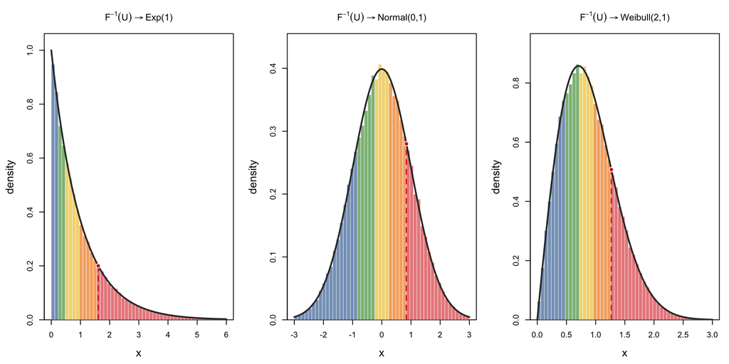

| Distribution | $F^{-1}(u)$ | Method |
| --- | --- | --- |
| Exp($\lambda$) | $-\frac{1}{\lambda}\log(1-u)$ | Analytic |
| Weibull($k,\lambda$) | $\lambda(-\log(1-u))^{1/k}$ | Analytic |
| Normal | No closed form | `qnorm` (numerical) |

```r
X_exp_inv  <- qexp(U,  rate = 1)
X_norm_inv <- qnorm(U)
X_wei_inv  <- qweibull(U, shape = 2, scale = 1)

band_cols <- c("#4E79A7","#59A14F","#EDC948","#F28E2B","#E15759")
tcol <- function(c,a) adjustcolor(c,alpha.f=a)
p5 <- seq(0,1,by=0.2)

# One panel: histogram with bars colored by their 20% probability band,
# gray theory curve on top, red dashed marker at F^-1(0.8).
band_hist <- function(x, qfun, dfun, main, xlim, bw){
  h <- hist(x[x>=xlim[1] & x<=xlim[2]], breaks=seq(xlim[1],xlim[2],by=bw), plot=FALSE)
  qs <- qfun(p5)                                   # band edges in x
  mids <- (h$breaks[-length(h$breaks)]+h$breaks[-1])/2
  cols <- tcol(band_cols[pmin(pmax(findInterval(mids,qs),1),5)],0.72)
  dens <- h$density*mean(x>=xlim[1] & x<=xlim[2])
  plot(NA,xlim=xlim,ylim=c(0,max(dens)*1.12),xlab=expression(x),ylab="density",
       main=main,yaxs="i")
  rect(h$breaks[-length(h$breaks)],0,h$breaks[-1],dens,col=cols,border="white",lwd=0.4)
  curve(dfun(x),xlim[1],xlim[2],add=TRUE,lwd=2.2,col="gray20")
  xs <- qfun(0.8)
  segments(xs,0,xs,dfun(xs),lty=2,col="#D62728",lwd=1.6)
  points(xs,dfun(xs),pch=21,bg="#D62728",col="white",cex=1.2)
}

par(mfrow=c(1,3),mar=c(4.6,4.6,3.5,1),cex.lab=1.35,cex.main=1.15,cex.axis=1.0)
band_hist(X_exp_inv,  function(p)qexp(p,1),      function(x)dexp(x,1),
          expression(F^{-1}*(U) %->% "Exp(1)"),        c(0,6),  0.12)
band_hist(X_norm_inv, qnorm,                      dnorm,
          expression(F^{-1}*(U) %->% "Normal(0,1)"),   c(-3,3), 0.12)
band_hist(X_wei_inv,  function(p)qweibull(p,2,1), function(x)dweibull(x,2,1),
          expression(F^{-1}*(U) %->% "Weibull(2,1)"),  c(0,3),  0.06)
```

## 2.2 幂变换：Exp → Weibull

Weibull 不仅可以通过逆 CDF 得到，也可以从 Exp 直接做幂变换：

若 $X \sim \text{Exp}(1)$，则 $Y = X^{1/k} \sim \text{Weibull}(k, 1)$。

Weibull 的核心概念是**风险率（hazard rate）**：

$$h(t) =
\frac{k}{\lambda}\left(\frac{t}{\lambda}\right)^{k-1}$$

- $k < 1$：风险递减 → 早期失效（婴儿死亡率）
- $k = 1$：风险恒定 → 指数分布（无记忆）
- $k > 1$：风险递增 → 老化磨损

### 2.2.1 密度、生存函数、风险率：同一批死亡的三种视角

hazard 和密度在图像上**不是积分关系，是除法**：$h=f/S$，等价地 $f=h\times S$。三个量描述同一批”死亡事件”，只差分母——密度按**全体**算，hazard 按**幸存者**算，$S$ 是幸存比例。积分藏在 $h\to S$ 那一步：$S(t)=e^{-\int_0^t h}$。

Weibull(2,1) 把这个关系画得最干净：$h(t)=2t$ 是一条**直线**（风险随年龄线性上升），$S(t)=e^{-t^2}$ 单调衰减，密度 = 两者**逐点相乘**——上升直线 × 衰减曲线 = 有峰的形状，峰就是两股力气打平的地方。下图灰色全是真实数据（同一批 $W=\sqrt{-\log(1-U)}$）：hazard 的灰点 = 每桶死亡数 ÷ 桶口幸存数 ÷ 桶宽，尾部发散是因为幸存者越来越少。红点全程追 $t=1$：$h=2,\ S=0.368,\ f=2\times0.368=0.736$。

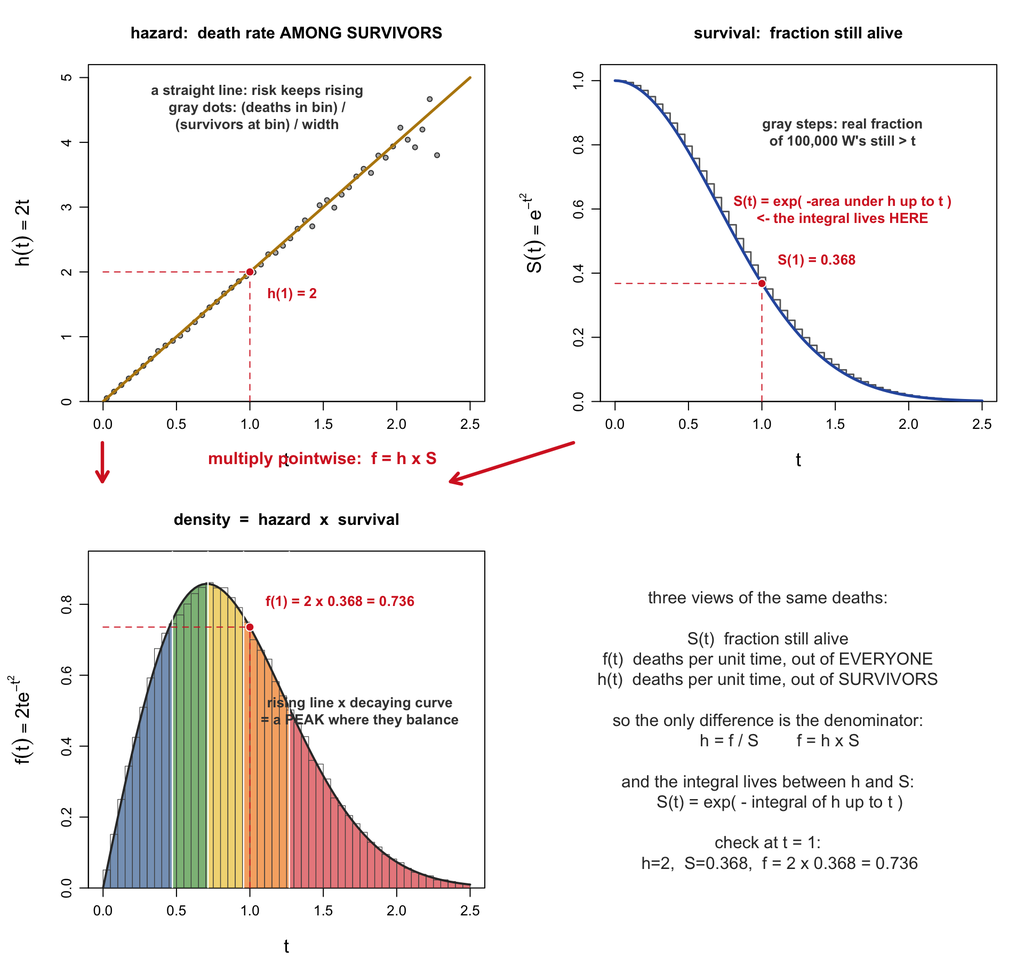

```r
k <- 2; lam <- 1; TM <- 2.5
W <- sqrt(-log(1-U))                       # Weibull(2,1) via power transform of Exp
prob_breaks <- seq(0,1,by=0.2); wq <- qweibull(prob_breaks,k,lam)
band_cols <- c("#4E79A7","#59A14F","#EDC948","#F28E2B","#E15759")
tcol <- function(c,a) adjustcolor(c,alpha.f=a)
RED<-"#D62728"; DRED<-"#7a1f1f"
t_star <- 1; h_star <- 2*t_star; S_star <- exp(-t_star^2); f_star <- h_star*S_star

layout(matrix(c(1,2, 3,4),2,2,byrow=TRUE))
par(cex.lab=1.35,cex.main=1.15,cex.axis=1.0,mgp=c(3,0.8,0))
MAR <- c(5.0,5.2,3.8,1.6)

# empirical hazard: deaths in bin / survivors at bin start / width
bw <- 0.05; br <- seq(0,2.3,by=bw); mids <- br[-length(br)]+bw/2
deaths <- hist(W[W<=2.3],breaks=br,plot=FALSE)$counts
alive  <- sapply(br[-length(br)],function(t) sum(W>=t))
h_emp <- (deaths/alive)/(1-deaths/alive/2)/bw   # actuarial: rate among survivors, midpoint-corrected

# (1) hazard
par(mar=MAR)
plot(NA,xlim=c(0,TM),ylim=c(0,5.2),xlab=expression(t),ylab=expression(h(t)==2*t),
     main="hazard:  death rate AMONG SURVIVORS",yaxs="i")
points(mids,h_emp,pch=21,bg=tcol("gray40",0.5),col="gray25",cex=0.75)
curve(2*x,0,TM,add=TRUE,lwd=2.6,col="#B8860B")
segments(t_star,0,t_star,h_star,lty=2,col=RED);segments(0,h_star,t_star,h_star,lty=2,col=RED)
points(t_star,h_star,pch=21,bg=RED,col="white",cex=1.3)
text(1.05,4.55,"a straight line: risk keeps rising\ngray dots: (deaths in bin) /\n(survivors at bin) / width",cex=1.0,col="gray25",font=2)
text(t_star+0.06,h_star-0.35,"h(1) = 2",cex=1.0,col=RED,font=2,pos=4)

# (2) survival
par(mar=MAR)
plot(NA,xlim=c(0,TM),ylim=c(0,1.05),xlab=expression(t),ylab=expression(S(t)==e^{-t^2}),
     main="survival:  fraction still alive",yaxs="i")
S_emp <- sapply(mids,function(t) mean(W>t))
lines(mids,S_emp,type="s",col="gray40",lwd=1.4)
curve(exp(-x^2),0,TM,add=TRUE,lwd=2.6,col="#2E5AAC")
segments(t_star,0,t_star,S_star,lty=2,col=RED);segments(0,S_star,t_star,S_star,lty=2,col=RED)
points(t_star,S_star,pch=21,bg=RED,col="white",cex=1.3)
text(1.55,0.84,"gray steps: real fraction\nof 100,000 W's still > t",cex=1.0,col="gray25",font=2)
text(1.55,0.60,"S(t) = exp( -area under h up to t )\n<- the integral lives HERE",cex=1.0,col="#D62728",font=2)
text(t_star+0.05,S_star+0.07,"S(1) = 0.368",cex=1.0,col=RED,font=2,pos=4)

# (3) density = hazard x survival
par(mar=MAR)
plot(NA,xlim=c(0,TM),ylim=c(0,0.95),xlab=expression(t),ylab=expression(f(t)==2*t*e^{-t^2}),
     main="density  =  hazard  x  survival",yaxs="i")
for(i in 1:5){l<-wq[i];r<-min(wq[i+1],TM);xx<-seq(l,r,length.out=150)
  polygon(c(l,xx,r),c(0,dweibull(xx,k,lam),0),col=tcol(band_cols[i],0.72),border=NA)}
hw <- hist(W[W<=TM],breaks=seq(0,TM,by=0.05),plot=FALSE)
rect(hw$breaks[-length(hw$breaks)],0,hw$breaks[-1],hw$density*mean(W<=TM),border="gray30",col=NA,lwd=0.6)
curve(dweibull(x,k,lam),0,TM,add=TRUE,lwd=2,col="gray20")
abline(v=wq[2:5],col="white",lwd=1.2)
segments(t_star,0,t_star,f_star,lty=2,col=RED);segments(0,f_star,t_star,f_star,lty=2,col=RED)
points(t_star,f_star,pch=21,bg=RED,col="white",cex=1.3)
text(1.75,0.50,"rising line x decaying curve\n= a PEAK where they balance",cex=1.0,col="gray25",font=2)
text(t_star+0.05,f_star+0.07,"f(1) = 2 x 0.368 = 0.736",cex=1.0,col=RED,font=2,pos=4)

# (4) text panel
par(mar=c(2,2,2,2))
plot(NA,xlim=c(0,1),ylim=c(0,1),xlab="",ylab="",main="",axes=FALSE)
text(0.5,0.5,paste0(
 "three views of the same deaths:\n\n",
 "S(t)  fraction still alive\n",
 "f(t)  deaths per unit time, out of EVERYONE\n",
 "h(t)  deaths per unit time, out of SURVIVORS\n\n",
 "so the only difference is the denominator:\n",
 "     h = f / S        f = h x S\n\n",
 "and the integral lives between h and S:\n",
 "     S(t) = exp( - integral of h up to t )\n\n",
 "check at t = 1:\n",
 "     h=2,  S=0.368,  f = 2 x 0.368 = 0.736"),cex=1.2,col="gray20")

# overlays
par(fig=c(0,1,0,1),new=TRUE,mar=c(0,0,0,0));plot(0:1,0:1,type="n",axes=FALSE,xlim=c(0,1),ylim=c(0,1),xaxs="i",yaxs="i")
# h down to density, S diagonally to density: multiply
arrows(0.10,0.545,0.10,0.505,length=0.11,lwd=3.2,col=RED)
arrows(0.56,0.545,0.44,0.505,length=0.11,lwd=3.2,col=RED)
text(0.315,0.528,"multiply pointwise:  f = h x S",cex=1.2,col=RED,font=2)
```

```r
layout(1)
```

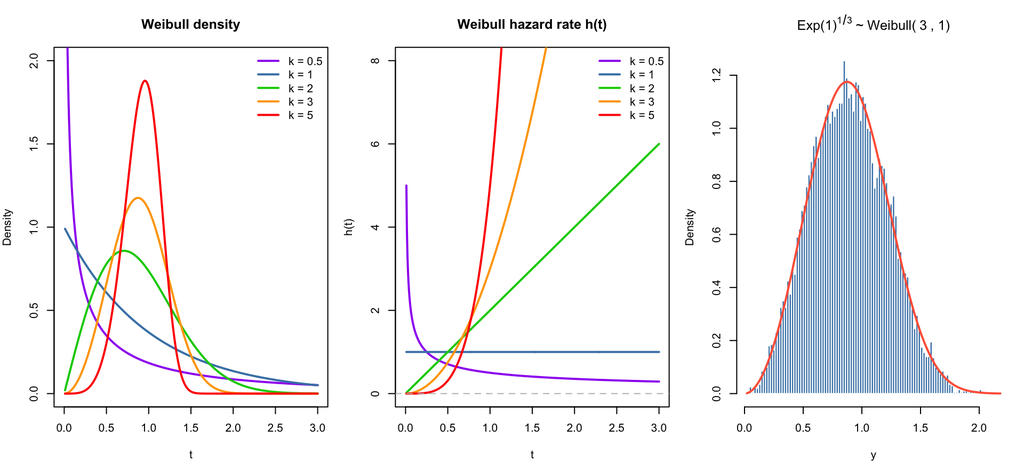

```r
x_seq <- seq(0.01, 3, length.out = 500)
ks    <- c(0.5, 1, 2, 3, 5)
cols  <- c("purple", "steelblue", "green3", "orange", "red")

par(mfrow = c(1, 3), mar = c(4, 4, 3.5, 1))

# Density
plot(NA, xlim = c(0, 3), ylim = c(0, 2),
     main = "Weibull density", xlab = "t", ylab = "Density")
for (i in seq_along(ks))
  lines(x_seq, dweibull(x_seq, ks[i], 1), col = cols[i], lwd = 2)
legend("topright", paste("k =", ks), col = cols, lwd = 2, bty = "n")

# Hazard rate
hazard_w <- function(x, k) k * x^(k - 1)
plot(NA, xlim = c(0, 3), ylim = c(0, 8),
     main = "Weibull hazard rate h(t)", xlab = "t", ylab = "h(t)")
for (i in seq_along(ks))
  lines(x_seq, hazard_w(x_seq, ks[i]), col = cols[i], lwd = 2)
abline(h = 0, col = "gray", lty = 2)
legend("topright", paste("k =", ks), col = cols, lwd = 2, bty = "n")

# Verify: Exp(1)^{1/k} ~ Weibull(k,1)
X_e <- rexp(10000)
k_demo <- 3
Y_w <- X_e^(1/k_demo)
hist(Y_w, breaks = 80, col = "steelblue", freq = FALSE, border = "white",
     main = bquote("Exp(1)"^{1/.(k_demo)} ~ "~ Weibull(" ~ .(k_demo) ~ ", 1)"),
     xlab = "y")
curve(dweibull(x, shape = k_demo, scale = 1), add = TRUE, col = "tomato", lwd = 2)
```

## 2.3 指数/对数变换：Normal ↔︎ LogNormal

若 $X \sim N(\mu, \sigma^2)$，则 $Y = e^X \sim \text{LogNormal}(\mu, \sigma^2)$。

现实中，当多个**乘法效应**叠加时（收入、文件大小、生物量），变量呈对数正态分布——因为取对数后就变成加法，CLT 生效。

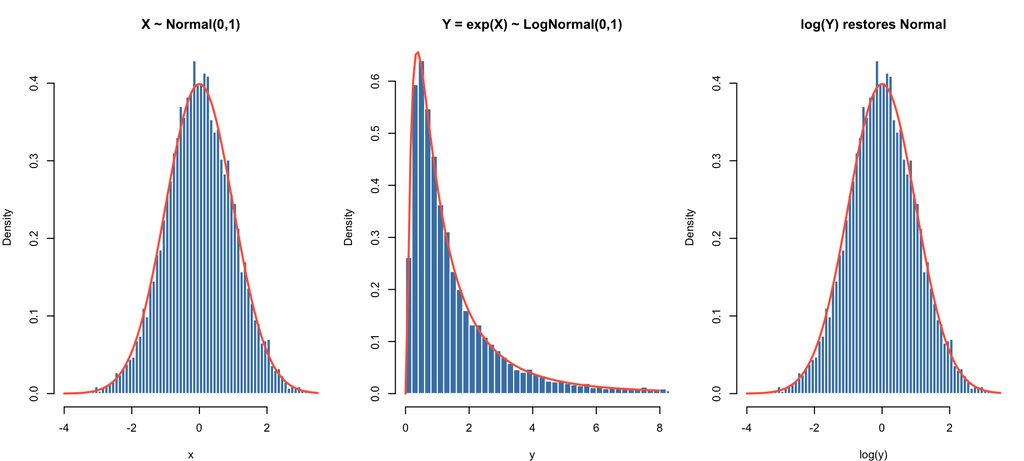

```r
mu <- 0; sigma <- 1
X_norm  <- rnorm(10000, mu, sigma)
Y_lnorm <- exp(X_norm)

par(mfrow = c(1, 3), mar = c(4, 4, 3.5, 1))

hist(X_norm, breaks = 60, col = "steelblue", freq = FALSE, border = "white",
     main = "X ~ Normal(0,1)", xlab = "x")
curve(dnorm(x, mu, sigma), add = TRUE, col = "tomato", lwd = 2)

hist(Y_lnorm, breaks = 120, col = "steelblue", freq = FALSE, border = "white",
     main = "Y = exp(X) ~ LogNormal(0,1)", xlab = "y",
     xlim = c(0, quantile(Y_lnorm, 0.98)))
curve(dlnorm(x, mu, sigma), add = TRUE, col = "tomato", lwd = 2)

hist(log(Y_lnorm), breaks = 60, col = "steelblue", freq = FALSE, border = "white",
     main = "log(Y) restores Normal", xlab = "log(y)")
curve(dnorm(x, mu, sigma), add = TRUE, col = "tomato", lwd = 2)
```

## 2.4 变换之间的层级关系

三种变换不是孤立的，它们有层级：

- **逆 CDF** 是万能方法（任何分布都可以）
- **幂变换** 是逆 CDF 的特例：Weibull 的 $F^{-1}(u) = (-\log(1-u))^{1/k}$ 就是先做 Exp 的逆 CDF $(-\log(1-u))$，再做幂 $({\cdot})^{1/k}$
- **指数变换** $e^X$ 把加法世界（Normal, CLT）映射到乘法世界（LogNormal）

$$\text{Uniform} \xrightarrow{-\log(1-U)}
\text{Exp} \xrightarrow{(\cdot)^{1/k}} \text{Weibull}$$
$$\text{Uniform} \xrightarrow{\texttt{qnorm}}
\text{Normal} \xrightarrow{e^{(\cdot)}} \text{LogNormal}$$

## 2.5 变换小结

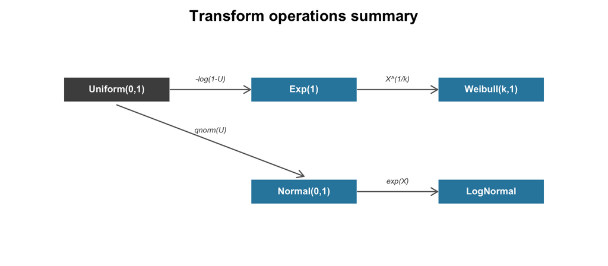

```r
par(mar = c(1, 1, 2, 1))
plot(NA, xlim = c(0, 10), ylim = c(0, 4), axes = FALSE, bty = "n",
     xlab = "", ylab = "", main = "Transform operations summary")

draw_box <- function(x, y, label, col, w = 2, h = 0.5) {
  rect(x-w/2, y-h/2, x+w/2, y+h/2, col = col, border = "white", lwd = 2)
  text(x, y, label, col = "white", font = 2, cex = 0.75)
}
arr <- function(x0, y0, x1, y1, lab = "") {
  arrows(x0, y0, x1, y1, length = 0.10, lwd = 1.5, col = "gray40")
  text((x0+x1)/2, (y0+y1)/2 + 0.2, lab, cex = 0.6, col = "gray30", font = 3)
}

draw_box(1.5, 3, "Uniform(0,1)", "gray30")
draw_box(5,   3, "Exp(1)",       "#2E86AB")
draw_box(8.5, 3, "Weibull(k,1)", "#2E86AB")
draw_box(5,   1, "Normal(0,1)",  "#2E86AB")
draw_box(8.5, 1, "LogNormal",    "#2E86AB")

arr(2.5, 3, 4, 3, "-log(1-U)")
arr(6,   3, 7.5, 3, "X^(1/k)")
arr(1.5, 2.7, 5, 1.3, "qnorm(U)")
arr(6,   1, 7.5, 1, "exp(X)")
```